# A Data Science Pipeline Tutorial on Fertility

In this tutorial, I will be exploring a fertility dataset based on WHO standards on sperm, which are diagnosed normal (N) or altered (O).

Author: Diana Shin  
Version: May 16th, 2021

## Introduction

Welcome to my data science pipeline tutorial, where I will be showing how to work with data from collection to analysis. The `fertility dataset` I will be using is from the `University of California, Irvine Machine Learning Repository` available here: [UCI Machine Learning Repository](https://archive.ics.uci.edu/ml/datasets/Fertility). This is a great repository to try out exploratory data analysis, and you can filter out datasets so that they are small and have anywhere from 10, to 100 or more columns/variables.

I recommend a few datasets that are interesting and have different types of data (categorical, numerical, words, etc):

- *Tic-tac-toe*, categorical play data that fits decision trees: [Tic-Tac-Toe Endgame Data Set](https://archive.ics.uci.edu/ml/datasets/Tic-Tac-Toe+Endgame)
- *Credit approval*, a mix of categorical data and numerical data prime for exploratory data analysis: [Credit Approval Data Set](https://archive.ics.uci.edu/ml/datasets/Credit+Approval)
- *NSF research abstracts*, a bag of words of various abstracts that received NSF awards, I recommend using the Natural Language Processing Toolkit (nltk) [NLTK Book](http://www.nltk.org/book/) with this project: [NSF Research Award Abstracts 1990-2003 Data Set](https://archive.ics.uci.edu/ml/datasets/NSF+Research+Award+Abstracts+1990-2003)

This tutorial will be following the data science pipeline:  
`Data Collection`  
`Data Processing`  
`Exploratory Analysis and Data Visualization`  
`Analysis, Hypothesis Testing, and ML`  
`Insight and Policy Decision`

### Motivation

For this data science pipeline tutorial, I chose this dataset because it had a mix of numerical and categorical data. In addition, it is an interesting topic to explore. Typically, we hear about fertility, but how much do we know about it? This dataset has a collection of approximately 100 semen samples from volunteers based on WHO standards, with variables ranging from their sitting and drinking habits, whether their fertility is normal, etc. From a CDC statistic survey in 2018, there were about 4 million births in 2014. *This tutorial could be helpful in exploring what could be helpful to the millions of people wanting to have a child.* Let's explore!

## Setup

Here are libraries that we need for the data science pipeline and their respective uses in the approximate order that they are used in this data science tutorial:

```python
import os # To automatically grab data
import pandas as pd # To wrangle data in tables
from pprint import pprint # For easier printing
import matplotlib.pyplot as plt # For plotting
import numpy as np # For calculations
from sklearn import linear_model # Regression
import scipy # Regression and stats tests
import statsmodels.api as sm # Hypothesis testing
from sklearn.model_selection import train_test_split # For training
from sklearn import tree # Making a decision tree
from sklearn.metrics import classification_report, confusion_matrix # Evaluating our decision tree
```

## Data Collection

To get the data from the UCI Machine Learning Repository, you could download the data from the *Data Folder* link, or you can use the `os` library to grab the data automatically. I am running on Linux, so I will be using wget to grab the dataset. There are lots of commands to work with your system as you grab and handle data, so I recommend looking at [SS64](https://ss64.com/bash/) if you are on a Linux system to get familiar with the commands used in this tutorial.

Before we start downloading the data used, I noticed that the column descriptions on the UCI website are not really complete, take the number of hours sitting what is 0-1 supposed to represent? Sometimes, you have to do more research about the data you are working with before you start to work with it if the descriptions are not fully present. So, I found the person who contributed this database to UCI and his related paper in *Oxford Academic* at [Semen Parameters Can Be Predicted from Environmental Factors and Lifestyle Using Artificial Intelligence Methods](https://academic.oup.com/biolreprod/article/88/4/99,%201-8/2514098), where in fact the number of hours was scaled on 0-1 based on a min max of 0-16 hours per day. Here is a complete list of the columns and how they were normalized in this dataset:

[figure not shown]

Feel free to refer to this throughout the tutorial for information about the columns in this data set.

```python
# Use the os system library and run a commmand like you would in the command shell
# In this case, we want to run wget <url_of_database_file_download>
os.system('wget https://archive.ics.uci.edu/ml/machine-learning-databases/00244/fertility_Diagnosis.txt')
```

```
0
```

```python
# Let's see our newly downloaded file in the directory by using the os library
current_directory = os.listdir() # Listdir lists files in the current directory
current_directory
```

```
['finaltutorial.ipynb',
 'fertility_Diagnosis.txt',
 'fertility_Diagnosis.txt.1',
 '.ipynb_checkpoints',
 'fertility_Diagnosis.txt.2',
 'full_description.png',
 'finaltutorial_webpage',
 'full_description.png:Zone.Identifier']
```

```python
# Let's take a peek at our file.
# We open the file and then read the next couple of lines using a list comprehension
with open("fertility_Diagnosis.txt") as preview:
    head = [next(preview) for x in range(0,5)]
pprint(head)
```

```
['-0.33,0.69,0,1,1,0,0.8,0,0.88,N\n',
 '-0.33,0.94,1,0,1,0,0.8,1,0.31,O\n',
 '-0.33,0.5,1,0,0,0,1,-1,0.5,N\n',
 '-0.33,0.75,0,1,1,0,1,-1,0.38,N\n',
 '-0.33,0.67,1,1,0,0,0.8,-1,0.5,O\n']
```

We can see that the file does not contain column names, but just comma separated values per row/observation. Looking back at the UCI website, we can see that the real columns are

- Season in which the analysis was performed. 1) winter, 2) spring, 3) Summer, 4) fall. (-1, -0.33, 0.33, 1)
- Age at the time of analysis. 18-36 (0, 1)
- Childish diseases (ie , chicken pox, measles, mumps, polio) 1) yes, 2) no. (0, 1)
- Accident or serious trauma 1) yes, 2) no. (0, 1)
- Surgical intervention 1) yes, 2) no. (0, 1)
- High fevers in the last year 1) less than three months ago, 2) more than three months ago, 3) no. (-1, 0, 1)
- Frequency of alcohol consumption 1) several times a day, 2) every day, 3) several times a week, 4) once a week, 5) hardly ever or never (0, 1)
- Smoking habit 1) never, 2) occasional 3) daily. (-1, 0, 1)
- Number of hours spent sitting per day ene-16 (0, 1)
- Output: Diagnosis normal (N), altered (O)

It is always a good idea to take a look at the data file, so you can load it into a database software like Pandas properly. For example, below we will be using the Pandas function `read_csv` to read this comma separated data, but we want to set the `header` to `None` so we don't accidently set an observation as the column names.

Here is a bad example of loading in the data (not considering that the column names are not in the comma separated text file):

```python
misload_df = pd.read_csv('fertility_Diagnosis.txt')
misload_df
```

|  | -0.33 | 0.69 | 0 | 1 | 1.1 | 0.1 | 0.8 | 0.2 | 0.88 | N |
| --- | --- | --- | --- | --- | --- | --- | --- | --- | --- | --- |
| 0 | -0.33 | 0.94 | 1 | 0 | 1 | 0 | 0.8 | 1 | 0.31 | O |
| 1 | -0.33 | 0.50 | 1 | 0 | 0 | 0 | 1.0 | -1 | 0.50 | N |
| 2 | -0.33 | 0.75 | 0 | 1 | 1 | 0 | 1.0 | -1 | 0.38 | N |
| 3 | -0.33 | 0.67 | 1 | 1 | 0 | 0 | 0.8 | -1 | 0.50 | O |
| 4 | -0.33 | 0.67 | 1 | 0 | 1 | 0 | 0.8 | 0 | 0.50 | N |
| ... | ... | ... | ... | ... | ... | ... | ... | ... | ... | ... |
| 94 | -1.00 | 0.67 | 1 | 0 | 0 | 0 | 1.0 | -1 | 0.50 | N |
| 95 | -1.00 | 0.61 | 1 | 0 | 0 | 0 | 0.8 | 0 | 0.50 | N |
| 96 | -1.00 | 0.67 | 1 | 1 | 1 | 0 | 1.0 | -1 | 0.31 | N |
| 97 | -1.00 | 0.64 | 1 | 0 | 1 | 0 | 1.0 | 0 | 0.19 | N |
| 98 | -1.00 | 0.69 | 0 | 1 | 1 | 0 | 0.6 | -1 | 0.19 | N |

99 rows × 10 columns

By not accounting for the file *not* containing the column names, we accidently set an observation as the column names (Note header defaults to 0, which is the first line in the file)! Below is the correct way to load the data, and we will be using the `fertility_df` as our main dataframe for the rest of the Jupyter notebook.

```python
# Use Pandas to put the data in a Pandas Dataframe
# Set header to "None" because we do not want Pandas to set the first row
# of the file to be the column names, we want to set them ourselves.
fertility_df = pd.read_csv('fertility_Diagnosis.txt', header=None)
fertility_df
```

|  | 0 | 1 | 2 | 3 | 4 | 5 | 6 | 7 | 8 | 9 |
| --- | --- | --- | --- | --- | --- | --- | --- | --- | --- | --- |
| 0 | -0.33 | 0.69 | 0 | 1 | 1 | 0 | 0.8 | 0 | 0.88 | N |
| 1 | -0.33 | 0.94 | 1 | 0 | 1 | 0 | 0.8 | 1 | 0.31 | O |
| 2 | -0.33 | 0.50 | 1 | 0 | 0 | 0 | 1.0 | -1 | 0.50 | N |
| 3 | -0.33 | 0.75 | 0 | 1 | 1 | 0 | 1.0 | -1 | 0.38 | N |
| 4 | -0.33 | 0.67 | 1 | 1 | 0 | 0 | 0.8 | -1 | 0.50 | O |
| ... | ... | ... | ... | ... | ... | ... | ... | ... | ... | ... |
| 95 | -1.00 | 0.67 | 1 | 0 | 0 | 0 | 1.0 | -1 | 0.50 | N |
| 96 | -1.00 | 0.61 | 1 | 0 | 0 | 0 | 0.8 | 0 | 0.50 | N |
| 97 | -1.00 | 0.67 | 1 | 1 | 1 | 0 | 1.0 | -1 | 0.31 | N |
| 98 | -1.00 | 0.64 | 1 | 0 | 1 | 0 | 1.0 | 0 | 0.19 | N |
| 99 | -1.00 | 0.69 | 0 | 1 | 1 | 0 | 0.6 | -1 | 0.19 | N |

100 rows × 10 columns

```python
# Update the column names in the dataframe to corresponding ones based on the UCI website
columns = ['season_of_analysis', 'age', 'childish_diseases', 'accident_trauma',
           'surgical_intervention', 'high_fever_LY', 'alcohol_consumption',
           'smoking_habit', 'hours_sitting_day', 'diagnosis']
fertility_df.columns = columns
fertility_df
```

|  | season_of_analysis | age | childish_diseases | accident_trauma | surgical_intervention | high_fever_LY | alcohol_consumption | smoking_habit | hours_sitting_day | diagnosis |
| --- | --- | --- | --- | --- | --- | --- | --- | --- | --- | --- |
| 0 | -0.33 | 0.69 | 0 | 1 | 1 | 0 | 0.8 | 0 | 0.88 | N |
| 1 | -0.33 | 0.94 | 1 | 0 | 1 | 0 | 0.8 | 1 | 0.31 | O |
| 2 | -0.33 | 0.50 | 1 | 0 | 0 | 0 | 1.0 | -1 | 0.50 | N |
| 3 | -0.33 | 0.75 | 0 | 1 | 1 | 0 | 1.0 | -1 | 0.38 | N |
| 4 | -0.33 | 0.67 | 1 | 1 | 0 | 0 | 0.8 | -1 | 0.50 | O |
| ... | ... | ... | ... | ... | ... | ... | ... | ... | ... | ... |
| 95 | -1.00 | 0.67 | 1 | 0 | 0 | 0 | 1.0 | -1 | 0.50 | N |
| 96 | -1.00 | 0.61 | 1 | 0 | 0 | 0 | 0.8 | 0 | 0.50 | N |
| 97 | -1.00 | 0.67 | 1 | 1 | 1 | 0 | 1.0 | -1 | 0.31 | N |
| 98 | -1.00 | 0.64 | 1 | 0 | 1 | 0 | 1.0 | 0 | 0.19 | N |
| 99 | -1.00 | 0.69 | 0 | 1 | 1 | 0 | 0.6 | -1 | 0.19 | N |

100 rows × 10 columns

## Data Processing

Luckily, this data is already 'tidy'. In addition, the columns have been normalized for us.

However, it is always important to check the data itself, for example, below I will be checking the data types of each column and also be checking for any missing data. We want to do this because we want to be familiar with our data and also because we want to make sure we are careful in our analysis if there is missing data.

```python
# Check the data types
fertility_df.dtypes
```

```
season_of_analysis       float64
age                      float64
childish_diseases          int64
accident_trauma            int64
surgical_intervention      int64
high_fever_LY              int64
alcohol_consumption      float64
smoking_habit              int64
hours_sitting_day        float64
diagnosis                 object
dtype: object
```

We can see that the data have mostly the correct types, however, the only one that is troublesome is the `diagnosis` column. Pandas actually has a a function `pandas.convert_dtypes()` which actually converts the columns to their ideal types ex. float, etc and also corrects any missing data like NaN to pd.NA. For example, we want `diagnosis` to be a string because it has N/O as its classfication values, not necessarily 'object'.

```python
# Maybe we don't want string to be counted as an object,
# let Pandas correct this for us.

# Often, you can just run convert_dtypyes() on a dataframe and
# Pandas will correct everything for you.

fertility_df = fertility_df.convert_dtypes()
fertility_df.dtypes
```

```
season_of_analysis       float64
age                      float64
childish_diseases          Int64
accident_trauma            Int64
surgical_intervention      Int64
high_fever_LY              Int64
alcohol_consumption      float64
smoking_habit              Int64
hours_sitting_day        float64
diagnosis                 string
dtype: object
```

In addition to making sure our columns have proper data types, it is important to check other aspects of our data. In the cell below, I want to check for any *missing data* that could affect our analysis (note, there is no missing data if you looked at the text file already, but this is just an example of it progmatically):

```python
# Check how many rows contain missing data

# We can do this by the Pandas is_null function, with any column
# containing a null value and sum the rows as such.
fertility_df.isnull().any(axis=1).sum()
```

```
0
```

## Exploratory Data Analysis and Visualization

In this dataset, we have the following data:

**Categorical**

- season_of_analysis
- childish_diseases
- accident_trauma
- surgical_intervention
- high_fever_LY
- alcohol_consumption
- smoking_habit
- *diagnosis*

**Numerical**

- age
- hours_sitting_day

First, I want to explore our `numerical variables` thorugh different plots:  
Questions we may want to ask:

- How do age and hours sitting per day relate?

  > Let's try making a scatter plot with some regression!
- How does age relate to the diagnosis?

  > Let's try to make a dot plot and visually see which points have N/O diagnosis.
- How does hours sitting per day relate to the diagnosis?

  > Let's try to make a dot plot and visually see which points have N/O diagnosis.

### Exploring `numerical variables`

**Exploring how age and hours relate**  
We often want to see relationships not only with the "end goal" data like `diagnosis`, but we also want to learn about other aspects of our data possible correlations. It could provide insight to other lines of research this dataset presents. Below, we are going to explore how age and hours relate by making a scatter plot and plotting different regressions. Later on in this tutorial, we will run statistical tests on the relationship we find.

```python
# Let's make a plot of age versus hours sitting per day

# Grab a dataframe consisting of age (variable), hours sitting (variable), and diagnosis (color-coordinator)
# Then, groupby diagnosis to color coordinate the points on the scatter plot.
age_hours_df = fertility_df[['age', 'hours_sitting_day', 'diagnosis']]
age_hours_groups = age_hours_df.groupby('diagnosis')
```

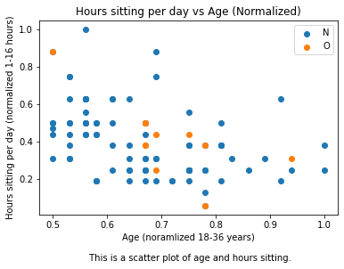

```python
# Make a figure and add a plot to it
fig = plt.figure()
age_hours_plot = fig.add_subplot(111)

# Scatter Plot
for key,data in age_hours_groups:
    # Plot X=age, Y=hours_sitting, label= diagnosis (we grouped by diagnosis in the previous cell)
    age_hours_plot.scatter(data['age'], data['hours_sitting_day'], label=key)

# Labeling our graph / giving context
age_hours_plot.legend()
age_hours_plot.set_xlabel("Age (noramlized 18-36 years)\n\n \
This is a scatter plot of age and hours sitting.")
age_hours_plot.set_ylabel("Hours sitting per day (normalized 1-16 hours)")
age_hours_plot.set_title('Hours sitting per day vs Age (Normalized)')

plt.show()
```

Why did we plot without the regression you may ask? It is important to first take a look at the data and see if it looks "linear", "quadratic" etc because you don't want to assume anything about the data before you even look at it. ' You could fall prey to *confirmation bias* if you think it works and don't consider other options. That being said, this data does look fairly linear or possible a very very slow logarithmic function, but let's try both to see which fits better!

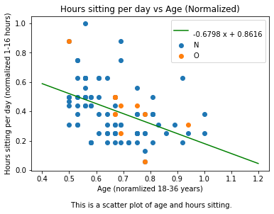

```python
# Linear Regression

# Can run NumPy's polyfit with 1 degree on it, it is a least squares regression.
p = np.poly1d(np.polyfit(age_hours_df['age'], age_hours_df['hours_sitting_day'], 1))
# Setting up a linspace for plotting
xp = np.linspace(0.4, 1.2, 100)

# Plot with xp (linspace) and the predicted values
age_hours_plot.plot(xp, p(xp), label=p, color='green')
age_hours_plot.legend()

fig
```

```python
# Logarithmic Regression

# Wrangle data to pass into function
x_vals = list()
y_vals = list()

for index,data in age_hours_df.iterrows():
    x_vals.append(data['age'])
    y_vals.append(data['hours_sitting_day'])
```

```python
# Run fit,
# Sometimes the function you want is not readily encoded
# for you in a library. So, you can use scipy with your own function
# that you want to fit.
scipy.optimize.curve_fit(lambda t,a,b: a+b*np.log(t),  x_vals,  y_vals)
# y ≈ 0.20271423 -0.48869888 log(x)

# Create a function to handle plotting (similar to p above)
def log_func(x):
    return 0.20271423 - 0.48869888*np.log(x)
```

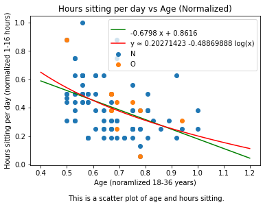

```python
# Logistic Regression Plot

# Defining our linspace
xp = np.linspace(0.4, 1.2, 100)

# Log prediction output list
ly  = list()

# Grab the log predictions
for x in xp:
    ly.append(log_func(x))


# Plot as before, adding the function to our legend
age_hours_plot.plot(xp, ly, label='y ≈ 0.20271423 -0.48869888 log(x)', color='red')
age_hours_plot.legend()

fig
```

We can see that there is not much difference between the logistic and linear graphs, but the logistic one does seem to fit the data better in this section.

Depending on your purposes, you could be fine choosing the linear model for a situation like this, but note that the logistic model is a better representation of the real-world on the right-end and the linear model is a better representation of the real-world on the left-end.

Another thing to note is that there is a cluster of abnormal semen around 0.7 in normalized age and 0.4 in normalized hours sitting per day. Maybe we can learn from it later on in our data science pipeline!

For the purposes of this data science tutorial, we will be continuing with the *linear approximation* because it is a simpler approximation, it fits our data visually, and it is easier to work with hypothesis tests.

**Exploring how age relates to diagnosis**  
We can actually make a dot plot / number line plot with matplotlib with a little effort! I learned a lot from this StackOverflow post [StackOverflow Dot Plot](https://stackoverflow.com/questions/49703938/how-to-create-a-dot-plot-in-matplotlib-not-a-scatter-plot) to make the below cell. We want to consider how age could possibly relate to diagnosis, while also getting a better sense of our data. Making a dot plot could be helpful in this and is feasible without having to make bins like with a histogram.

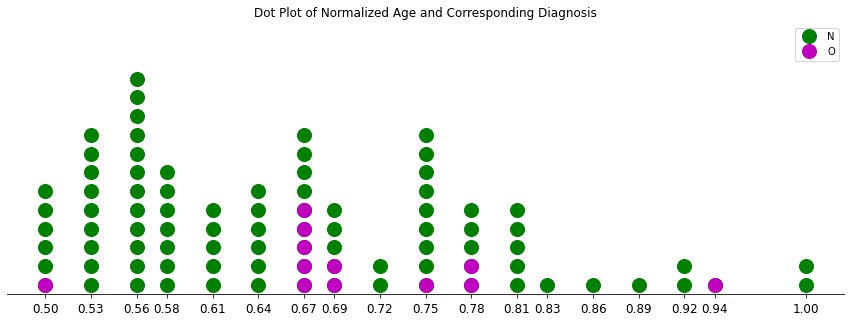

```python
# Let's make a number line / dot plot of the age and see how it relates to diagnosis
values, counts = np.unique(age_hours_df['age'], return_counts=True)
fig, ax = plt.subplots(figsize=(15, 5))

# Count how many are N/O diagnosis by grabbing N counts
diag = list()
for val in values:
    N = age_hours_df.loc[(age_hours_df['age'] == val) & (age_hours_df['diagnosis'] == 'N')].any(axis=1).sum()
    diag.append(N)

# Added to legend boolean variable: because
# we are runnign plot in a for loop, we only want to add the label to the legend
# if it is not already there.
legend_fulfilled = False

# In this for loop we will be going through the values
# plotting based on N/O where diag is the number of 'N' diags
for value, count, diag in zip(values, counts, diag):
    if legend_fulfilled == False:
        plt.plot([value]*(diag), list(range(diag)), 'go', ms=14, linestyle='', label='N')
        plt.plot([value]*(count - diag), list(range(count - diag)), 'mo', ms=14, linestyle='', label='O')
        legend_fulfilled = True
    else:
        plt.plot([value]*(diag), list(range(diag)), 'go', ms=14, linestyle='')
        plt.plot([value]*(count - diag), list(range(count - diag)), 'mo', ms=14, linestyle='')

# Make it cleaner by removing the spines of the graph
for spine in ['top', 'right', 'left']:
    ax.spines[spine].set_visible(False)

# Add context to the graph
ax.yaxis.set_visible(False)
ax.set_ylim(-0.5, max(counts))
ticks = list(values)
ticks.sort()
ax.set_xticks(ticks)
ax.tick_params(axis='x', pad=5, labelsize=12)
ax.set_title('Dot Plot of Normalized Age and Corresponding Diagnosis')
ax.legend()

plt.show()
```

What we can learn from it:  
We can see that there seems to be a cluster around 0.67 and 0.69 of altered sperm (not normal). This corresponds to 0.67*36 and .69*36 which is 24.12 and 24.84. But! We have to notice that these age groups are more represented in the data set, though still not super tall like 0.56, so if you have more people you will have more instances of not normal sperm. But this is something to take note of because it is *unusual*!

**Exploring how hours sitting relates to diagnosis**  
In addition to exploring age, does how many hours you sit in a day relate to your diagnosis? We will repeat the process as before and try to see if there is a visually discernable spike or trend.

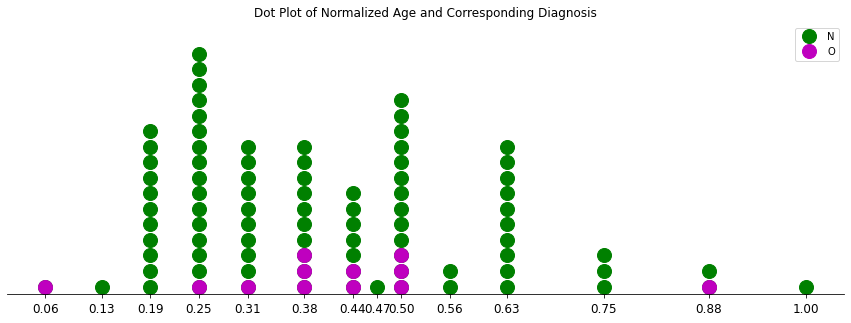

```python
# Let's make a number line / dot plot of the age and see how it relates to diagnosis
values, counts = np.unique(age_hours_df['hours_sitting_day'], return_counts=True)
fig, ax = plt.subplots(figsize=(15, 5))

# Count how many are N/O diagnosis by grabbing N counts
diag = list()
for val in values:
    N = age_hours_df.loc[(age_hours_df['hours_sitting_day'] == val) & (age_hours_df['diagnosis'] == 'N')].any(axis=1).sum()
    diag.append(N)

# Added to legend, boolean variable
legend_fulfilled = False

# Plot our points using a for loop
for value, count, diag in zip(values, counts, diag):
    if legend_fulfilled == False:
        plt.plot([value]*(diag), list(range(diag)), 'go', ms=14, linestyle='', label='N')
        plt.plot([value]*(count - diag), list(range(count - diag)), 'mo', ms=14, linestyle='', label='O')
        legend_fulfilled = True
    else:
        plt.plot([value]*(diag), list(range(diag)), 'go', ms=14, linestyle='')
        plt.plot([value]*(count - diag), list(range(count - diag)), 'mo', ms=14, linestyle='')

# Remove spines
for spine in ['top', 'right', 'left']:
    ax.spines[spine].set_visible(False)

# Context
ax.yaxis.set_visible(False)
ax.set_ylim(-0.5, max(counts))
ticks = list(values)
ticks.sort()
ax.set_xticks(ticks)
ax.tick_params(axis='x', pad=5, labelsize=12)
ax.set_title('Dot Plot of Normalized Age and Corresponding Diagnosis')
ax.legend()

plt.show()
```

What we can learn from it: actually not very much. There just seems to be more purple sperm with more participants in an age group. I don't think we can learn much from it.

Now that we have investigated our numerical data and saw something interesting from age in particular, let's look at our categorical variables to see if there is anything interesting happening there!

To remind ourselves of our categorical variables:

**Categorical**

- season_of_analysis
- childish_diseases
- accident_trauma
- surgical_intervention
- high_fever_LY
- alcohol_consumption
- smoking_habit
- *diagnosis*

### Exploring `categorical variables`

In this section I will be grabbing sub data frames by their diagnosis, called N_sub and O-sub to get different counts / proportions of the diagnosis in relative dataframes to our categorical variables. Sometimes, grabbing sub dataframes gives us more freedom in our code to wrangle with the data.

We are interested in grabbing separate dataframes and wrangling them because we want to see how different categories for each of our categorical variables could possibly affect diagnosis as normal or altered.

After working with the data, I then plotted each categorical variable and their normalized freqeuncies of N/O per category in a bar chart to visually see the distribution of the N/O diagnosis of sperm.

*Why normalized, why approach it this way?* Again we care about the distribution of the normal/altered sperm per category. Some categories will have more people in it than others, and can make us think that those categories have more weight just by the number of people. However, we want to see the distribution of N/Os which requires us to normalize based on # people per category to see percentages of normal and abnormal sperm in that category. In the bar charts below, consider what could happen if we didn't normalize our data beforehand.

```python
# Grab subsets of N and O diagnoses
N_sub = fertility_df.loc[(fertility_df['diagnosis'] == 'N')]
O_sub = fertility_df.loc[(fertility_df['diagnosis'] == 'O')]
```

```python
# Grab the dataframe consisting of counts
# We want to grab a subset of the season_of_analysis plus some column (it really doesn't matter)
# to use as our count of the different categories for season of analysis.
season_of_analysis_N = N_sub[['season_of_analysis', 'diagnosis']].groupby('season_of_analysis').count()

# Here is our result
season_of_analysis_N.columns = ['N']
season_of_analysis_N
```

| season_of_analysis | N |
| --- | --- |
| -1.00 | 27 |
| -0.33 | 33 |
| 0.33 | 3 |
| 1.00 | 25 |

```python
# Let's do the same thing for season of analysis 'O'
season_of_analysis_O = O_sub[['season_of_analysis', 'diagnosis']].groupby('season_of_analysis').count()

# Here is our result
season_of_analysis_O.columns = ['O']
season_of_analysis_O
```

| season_of_analysis | O |
| --- | --- |
| -1.00 | 1 |
| -0.33 | 4 |
| 0.33 | 1 |
| 1.00 | 6 |

```python
# Let's combine our analysis and also normalize our data to be percentages per season / category:
season_of_analysis = season_of_analysis_N.join(season_of_analysis_O)
season_of_analysis['total'] = season_of_analysis['N'] + season_of_analysis['O']
season_of_analysis['N_normal'] = season_of_analysis['N'] / season_of_analysis['total']
season_of_analysis['O_normal'] = season_of_analysis['O'] / season_of_analysis['total']
season_of_analysis
```

| season_of_analysis | N | O | total | N_normal | O_normal |
| --- | --- | --- | --- | --- | --- |
| -1.00 | 27 | 1 | 28 | 0.964286 | 0.035714 |
| -0.33 | 33 | 4 | 37 | 0.891892 | 0.108108 |
| 0.33 | 3 | 1 | 4 | 0.750000 | 0.250000 |
| 1.00 | 25 | 6 | 31 | 0.806452 | 0.193548 |

```python
# We are going to repeat the process of what we did above as for other categorical variables in this dataset.

# Childish diseases
childish_diseases_N = N_sub[['childish_diseases', 'diagnosis']].groupby('childish_diseases').count()
childish_diseases_N.columns = ['N']
childish_diseases_O = O_sub[['childish_diseases', 'diagnosis']].groupby('childish_diseases').count()
childish_diseases_O.columns = ['O']
childish_diseases = childish_diseases_N.join(childish_diseases_O)
childish_diseases['total'] = childish_diseases['N'] + childish_diseases['O']
childish_diseases['N_normal'] = childish_diseases['N'] / childish_diseases['total']
childish_diseases['O_normal'] = childish_diseases['O'] / childish_diseases['total']

# Accidents / Serious Trauma
accident_trauma_N = N_sub[['accident_trauma', 'diagnosis']].groupby('accident_trauma').count()
accident_trauma_N.columns = ['N']
accident_trauma_O = O_sub[['accident_trauma', 'diagnosis']].groupby('accident_trauma').count()
accident_trauma_O.columns = ['O']
accident_trauma = accident_trauma_N.join(accident_trauma_O)
accident_trauma['total'] = accident_trauma['N'] + accident_trauma['O']
accident_trauma['N_normal'] = accident_trauma['N'] / accident_trauma['total']
accident_trauma['O_normal'] = accident_trauma['O'] / accident_trauma['total']

# Surgical intervention
surgical_intervention_N = N_sub[['surgical_intervention', 'diagnosis']].groupby('surgical_intervention').count()
surgical_intervention_N.columns = ['N']
surgical_intervention_O = O_sub[['surgical_intervention', 'diagnosis']].groupby('surgical_intervention').count()
surgical_intervention_O.columns = ['O']
surgical_intervention = surgical_intervention_N.join(surgical_intervention_O)
surgical_intervention['total'] = surgical_intervention['N'] + surgical_intervention['O']
surgical_intervention['N_normal'] = surgical_intervention['N'] / surgical_intervention['total']
surgical_intervention['O_normal'] = surgical_intervention['O'] / surgical_intervention['total']

# High fever in the last year
high_fever_LY_N = N_sub[['high_fever_LY', 'diagnosis']].groupby('high_fever_LY').count()
high_fever_LY_N.columns = ['N']
high_fever_LY_O = O_sub[['high_fever_LY', 'diagnosis']].groupby('high_fever_LY').count()
high_fever_LY_O.columns = ['O']
high_fever_LY = high_fever_LY_N.join(high_fever_LY_O)
high_fever_LY['total'] = high_fever_LY['N'] + high_fever_LY['O']
high_fever_LY['N_normal'] = high_fever_LY['N'] / high_fever_LY['total']
high_fever_LY['O_normal'] = high_fever_LY['O'] / high_fever_LY['total']

# Alcohol consumption
alcohol_consumption_N = N_sub[['alcohol_consumption', 'diagnosis']].groupby('alcohol_consumption').count()
alcohol_consumption_N.columns = ['N']
alcohol_consumption_O = O_sub[['alcohol_consumption', 'diagnosis']].groupby('alcohol_consumption').count()
alcohol_consumption_O.columns = ['O']
alcohol_consumption = alcohol_consumption_N.join(alcohol_consumption_O)
alcohol_consumption['total'] = alcohol_consumption['N'] + alcohol_consumption['O']
alcohol_consumption['N_normal'] = alcohol_consumption['N'] / alcohol_consumption['total']
alcohol_consumption['O_normal'] = alcohol_consumption['O'] / alcohol_consumption['total']


# Smoking habits
smoking_habit_N = N_sub[['smoking_habit', 'diagnosis']].groupby('smoking_habit').count()
smoking_habit_N.columns = ['N']
smoking_habit_O = O_sub[['smoking_habit', 'diagnosis']].groupby('smoking_habit').count()
smoking_habit_O.columns = ['O']
smoking_habit = smoking_habit_N.join(smoking_habit_O)
smoking_habit['total'] = smoking_habit['N'] + smoking_habit['O']
smoking_habit['N_normal'] = smoking_habit['N'] / smoking_habit['total']
smoking_habit['O_normal'] = smoking_habit['O'] / smoking_habit['total']
```

Now that we have wrangled our data, let's plot it! We are going to plot normalized / scaled out of 100% to just tell the frequencies of normal or altered sperm between cateogries, we do not want to be swayed by the total counts, because that is not related to the frequency of which the diagnosis occurs in different categories.

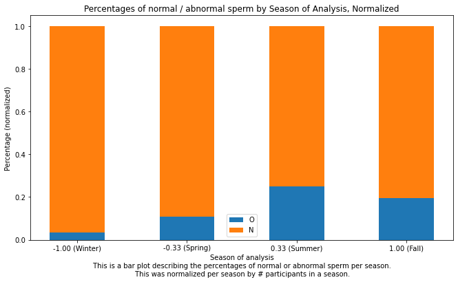

```python
# Season of analysis
fig, ax = plt.subplots(figsize=(11, 6))

# Grab normalized values
O_vals = season_of_analysis['O_normal'].values
N_vals = season_of_analysis['N_normal'].values

# Plot using matplotlib
ax.bar(range(len(O_vals)), O_vals, width=.5)
ax.bar(range(len(N_vals)), N_vals, bottom=O_vals, width=.5)

# Labeling
plt.xticks([0,1,2,3],['-1.00 (Winter)', '-0.33 (Spring)', '0.33 (Summer)', '1.00 (Fall)'])

ax.set_ylabel('Percentage (normalized)')
ax.set_xlabel('Season of analysis\n \
This is a bar plot describing the percentages of normal or abnormal sperm per season. \n \
This was normalized per season by # participants in a season.')
ax.set_title('Percentages of normal / abnormal sperm by Season of Analysis, Normalized')

plt.legend(labels=['O', 'N'])

plt.show()
```

What we can learn from it: We see higher percentages of sperm in summer and fall and a dip in winter! Maybe that could mean something. We can take note of this variable for now and test it later with a significance test.

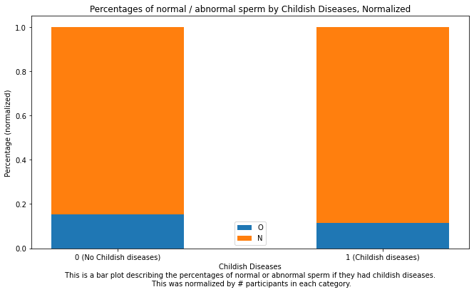

```python
# Childish diseases
fig, ax = plt.subplots(figsize=(11, 6))

# Grab normalized values
O_vals = childish_diseases['O_normal'].values
N_vals = childish_diseases['N_normal'].values

# Plot using matplotlib
ax.bar(range(len(O_vals)), O_vals, width=.5)
ax.bar(range(len(N_vals)), N_vals, bottom=O_vals, width=.5)

# Labeling
plt.xticks([0,1],['0 (No Childish diseases)', '1 (Childish diseases)'])

ax.set_ylabel('Percentage (normalized)')
ax.set_xlabel('Childish Diseases\n \
This is a bar plot describing the percentages of normal or abnormal sperm if they had childish diseases. \n \
This was normalized by # participants in each category.')
ax.set_title('Percentages of normal / abnormal sperm by Childish Diseases, Normalized')

plt.legend(labels=['O', 'N'])

plt.show()
```

What we can learn from it: Childish diseases do not really play a role in weather or not the sperm is normal or abnormal. Just visually, the bar plots look almost exactly the same.

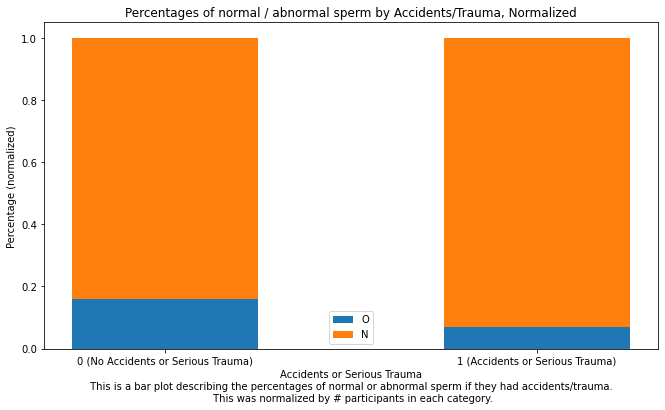

```python
# Accidents or Serious Trauma
fig, ax = plt.subplots(figsize=(11, 6))

# Grab normalized values
O_vals = accident_trauma['O_normal'].values
N_vals = accident_trauma['N_normal'].values

# Plot using matplotlib
ax.bar(range(len(O_vals)), O_vals, width=.5)
ax.bar(range(len(N_vals)), N_vals, bottom=O_vals, width=.5)

# Labeling
plt.xticks([0,1],['0 (No Accidents or Serious Trauma)', '1 (Accidents or Serious Trauma)'])

ax.set_ylabel('Percentage (normalized)')
ax.set_xlabel('Accidents or Serious Trauma\n \
This is a bar plot describing the percentages of normal or abnormal sperm if they had accidents/trauma. \n \
This was normalized by # participants in each category.')
ax.set_title('Percentages of normal / abnormal sperm by Accidents/Trauma, Normalized')

plt.legend(labels=['O', 'N'])

plt.show()
```

What we can learn from it: It does seem weird that people with no accidents or trauma have a higher percentage of abnormal sperm. It does look pretty different, so let's save it for a statistical test later!

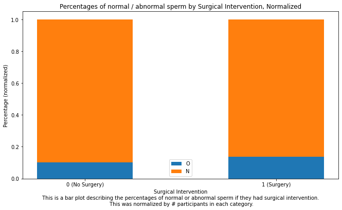

```python
# Surgical Intervention
fig, ax = plt.subplots(figsize=(11, 6))

# Grab normalized values
O_vals = surgical_intervention['O_normal'].values
N_vals = surgical_intervention['N_normal'].values

# Plot using matplotlib
ax.bar(range(len(O_vals)), O_vals, width=.5)
ax.bar(range(len(N_vals)), N_vals, bottom=O_vals, width=.5)

# Labeling
plt.xticks([0,1],['0 (No Surgery)', '1 (Surgery)'])

ax.set_ylabel('Percentage (normalized)')
ax.set_xlabel('Surgical Intervention\n \
This is a bar plot describing the percentages of normal or abnormal sperm if they had surgical intervention. \n \
This was normalized by # participants in each category.')
ax.set_title('Percentages of normal / abnormal sperm by Surgical Intervention, Normalized')

plt.legend(labels=['O', 'N'])

plt.show()
```

What we can learn from it: It doesn't seem to be that surgical intervention has an impact on sperm diagnosis.

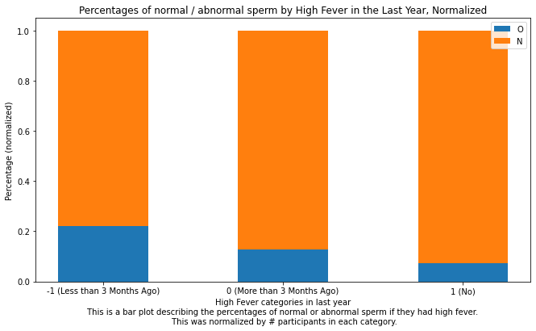

```python
# High Fever in the Last Year
fig, ax = plt.subplots(figsize=(11, 6))

# Grab normalized values
O_vals = high_fever_LY['O_normal'].values
N_vals = high_fever_LY['N_normal'].values

# Plot using matplotlib
ax.bar(range(len(O_vals)), O_vals, width=.5)
ax.bar(range(len(N_vals)), N_vals, bottom=O_vals, width=.5)

# Labeling
plt.xticks([0,1,2],['-1 (Less than 3 Months Ago)', '0 (More than 3 Months Ago)','1 (No)'])

ax.set_ylabel('Percentage (normalized)')
ax.set_xlabel('High Fever categories in last year\n \
This is a bar plot describing the percentages of normal or abnormal sperm if they had high fever. \n \
This was normalized by # participants in each category.')
ax.set_title('Percentages of normal / abnormal sperm by High Fever in the Last Year, Normalized')

plt.legend(labels=['O', 'N'])

plt.show()
```

What we can learn from it: There seems to be a slightly higher percentage of abnormal sperm if the person had a gever in the last year, even *more* so when we look at less than three months ago. We can continue with a statistical test later in our data science pipeline.

`Alcohol consumption` is weird, before I plotted, I previewed every single data frame to make sure all the numbers are right, however, take a look here.  
In fact, there are not enough samples in 0.2 and 0.4 to really have good data (1 in N for each no data for O). So, we shouldn't be looking at it because it could skew our view. Although data is not technically 'missing' in the sense that we checked for NaNs earlier in this tutorial, we still do not have a lot of data in all of the categories.

```python
alcohol_consumption
```

| alcohol_consumption | N | O | total | N_normal | O_normal |
| --- | --- | --- | --- | --- | --- |
| 0.2 | 1 | NaN | NaN | NaN | NaN |
| 0.4 | 1 | NaN | NaN | NaN | NaN |
| 0.6 | 15 | 4.0 | 19.0 | 0.789474 | 0.210526 |
| 0.8 | 33 | 6.0 | 39.0 | 0.846154 | 0.153846 |
| 1.0 | 38 | 2.0 | 40.0 | 0.950000 | 0.050000 |

In our plot, I will put empty bars in for alcohol consumption 0.2 and 0.4 (not enough data because literally only 1 sample) and bars for the rest.

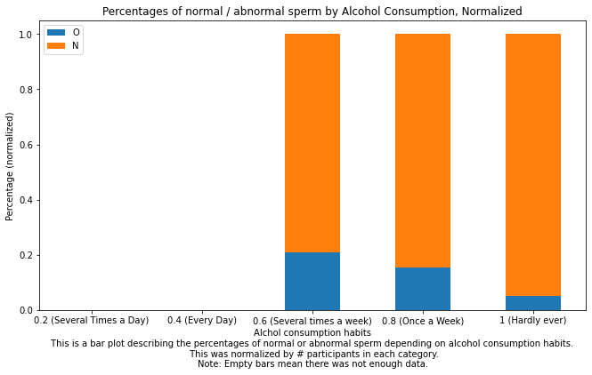

```python
# Alcohol Consumption
fig, ax = plt.subplots(figsize=(11, 6))

# Grab noramalized values, artifically setting first two columns to 0
O_vals = [0,0] + list(alcohol_consumption['O_normal'].values[2:])
N_vals = [0,0] + list(alcohol_consumption['N_normal'].values[2:])

# Plotting
ax.bar(range(len(O_vals)), O_vals, width=.5)
ax.bar(range(len(N_vals)), N_vals, bottom=O_vals, width=.5)

# Labeling
plt.xticks([0,1,2,3,4],['0.2 (Several Times a Day)', '0.4 (Every Day)',
                        '0.6 (Several times a week)', '0.8 (Once a Week)', '1 (Hardly ever)'])

ax.set_ylabel('Percentage (normalized)')
ax.set_xlabel('Alchol consumption habits\n \
This is a bar plot describing the percentages of normal or abnormal sperm \
depending on alcohol consumption habits. \n \
This was normalized by # participants in each category.\n\
Note: Empty bars mean there was not enough data.')
ax.set_title('Percentages of normal / abnormal sperm by Alcohol Consumption, Normalized')

plt.legend(labels=['O', 'N'])

plt.show()
```

What we can learn from this, possibly more drinking means that you have a higher risk for abnormal sperm.

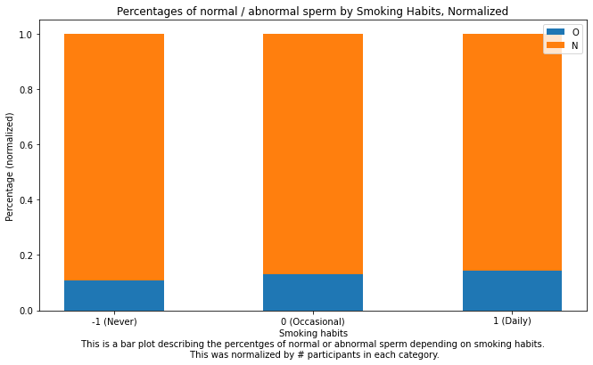

```python
# Smoking habits
fig, ax = plt.subplots(figsize=(11, 6))

# Grab normalized variables
O_vals = smoking_habit['O_normal'].values
N_vals = smoking_habit['N_normal'].values

# Plotting
ax.bar(range(len(O_vals)), O_vals, width=.5)
ax.bar(range(len(N_vals)), N_vals, bottom=O_vals, width=.5)

# Labeling
plt.xticks([0,1,2],['-1 (Never)', '0 (Occasional)', '1 (Daily)'])

ax.set_ylabel('Percentage (normalized)')
ax.set_xlabel('Smoking habits\n \
This is a bar plot describing the percentges of normal or abnormal sperm \
depending on smoking habits. \n \
This was normalized by # participants in each category.')
ax.set_title('Percentages of normal / abnormal sperm by Smoking Habits, Normalized')

plt.legend(labels=['O', 'N'])

plt.show()
```

What we can learn from it: It does not seem to be thar smoking habits has an impact on diagnosis but could be interesting to explore.

## Analysis, Hypothesis Testing, and ML

**Analysis of our Visualizations and Models**  
In this section: I want to talk about some things we noticed from our Exploratory Data Analysis.

In terms of relationships *between* our numerical variables of age and number of hours sitting in a day, we found that there was approximately a linear relationship between age and the number of hours you sit in a day. Although this insight is separate from the actual diagnosis, it is still interesting to note how age and a behavior like hours sitting relates.

In terms of possible relationships between age and diagnosis of normal or abnormal sperm around 24 years old, there was a larger portion of abnormal sperm compared to other age groups. Between hours sitting in a day and diagnosis, we didn't really see a correlation between the two.

Impact on `diagnosis`:

Among numerical variables: maybe `age` has an impact?

Now, onto our categorical variables. Earlier in our Exploratory Data Analysis, we analyzed if there were possible connections between the catgories for a particular variable and the diagnosis of sperm (normalized to be percentages out of 100). Among our visualizations, we found that `season of analysis`, `serious accidents or trauma`, `high fever in the last year` and `alcohol consumption` seemed to have the most affect on diagnosis of sperm.

**Hypothesis Testing**  
We did a series of analyses above based on our EDA, but let's try to run hypothesis tests on what we thought to see if our insight is *significant*. I recommend looking at hypothesis tests you can do on various data science websites, here is one that I will be referencing for this tutorial: [Determining the Statistical Test to Use fo Hypothesis Testing](https://towardsdatascience.com/how-to-know-which-statistical-test-to-use-for-hypothesis-testing-744c91685a5d).

Here are the series of hypothesis tests we will be conducting:

- Hypothesis test of linear correlation between age and hours sitting (aside but interesting to see)
- Hypothesis test of age and diagnosis
- Hypothesis test of season of analysis and diagnosis
- Hypothesis test of serious accidents or trauma and diagnosis
- Hypothesis test of high fever in the last year and diagnosis
- Hypothesis test of alcohol consumption and diagnosis

In the tests I will be following a standard 5% significance level.

*Hypothesis test of linear correlation between age and hours sitting (aside but interesting to see)*  
Below, I will be using the statsmodels library in order to conduct a hypothesis test on our data. Statsmodels runs the regression and t-test for us so we can just analyze the output. We want to run a hypothesis test to see if what we encountered was due to chance or not on a 5% significance level.

```python
# Grabbing our data
X = age_hours_df['age']
Y = age_hours_df['hours_sitting_day']

# Add intercept
X = sm.add_constant(X)

# Fit the model
model = sm.OLS(Y,X)
results = model.fit()

# Print out information regarding it
# includes p value
results.summary()
```

OLS Regression Results

| Dep. Variable: | hours_sitting_day | R-squared: | 0.196 |
| --- | --- | --- | --- |
| Model: | OLS | Adj. R-squared: | 0.188 |
| Method: | Least Squares | F-statistic: | 23.85 |
| Date: | Sun, 16 May 2021 | Prob (F-statistic): | 4.04e-06 |
| Time: | 19:32:49 | Log-Likelihood: | 37.490 |
| No. Observations: | 100 | AIC: | -70.98 |
| Df Residuals: | 98 | BIC: | -65.77 |
| Df Model: | 1 |  |  |
| Covariance Type: | nonrobust |  |  |

|  | coef | std err | t | P>\|t\| | [0.025 | 0.975] |
| --- | --- | --- | --- | --- | --- | --- |
| const | 0.8616 | 0.095 | 9.106 | 0.000 | 0.674 | 1.049 |
| age | -0.6798 | 0.139 | -4.884 | 0.000 | -0.956 | -0.404 |

| Omnibus: | 9.783 | Durbin-Watson: | 1.957 |
| --- | --- | --- | --- |
| Prob(Omnibus): | 0.008 | Jarque-Bera (JB): | 9.677 |
| Skew: | 0.704 | Prob(JB): | 0.00792 |
| Kurtosis: | 3.583 | Cond. No. | 12.0 |

Notes:  
[1] Standard Errors assume that the covariance matrix of the errors is correctly specified.

The p value is approximately 0, so we reject the null hypothesis that the correlation coefficient between age and hours sitting per day is 0. This means that the linear correlation we found between age and hours sitting down is linear! However, it is always important to note that our dataset only includes individuals aged 18-36 and should only be considered for that age range.

*Hypothesis test of age and diagnosis*

Exploration of an unusual hypothesis testing method (not the best for our purposes): I will be using the LogitModel from statsmodels to show how age increases the *odds* of a normal diagnosis (1) from abnormal (0). For more information and a full tutorial on this process I recommend UCLA data science tutorials, for example [UCLA Logit Regression](https://stats.idre.ucla.edu/r/dae/logit-regression/), is a great tutorial for this type of hypothesis test.

```python
# Let's wrangle out the data we want from our original dataset
hyp_age_diag = fertility_df[['age', 'diagnosis']]
hyp_age_diag
```

|  | age | diagnosis |
| --- | --- | --- |
| 0 | 0.69 | N |
| 1 | 0.94 | O |
| 2 | 0.50 | N |
| 3 | 0.75 | N |
| 4 | 0.67 | O |
| ... | ... | ... |
| 95 | 0.67 | N |
| 96 | 0.61 | N |
| 97 | 0.67 | N |
| 98 | 0.64 | N |
| 99 | 0.69 | N |

100 rows × 2 columns

```python
# We want to recast our diagnosis to be 1s and 0s to run with statsmodel

# Can use pandas to do this for us
# Ex. we want to replace 'N' instances with numerical 1,
# and we want to change inplace (the actual dataframe)
hyp_age_diag = hyp_age_diag.replace(to_replace='N', value=1)
hyp_age_diag = hyp_age_diag.replace(to_replace='O', value=0)
hyp_age_diag
```

|  | age | diagnosis |
| --- | --- | --- |
| 0 | 0.69 | 1 |
| 1 | 0.94 | 0 |
| 2 | 0.50 | 1 |
| 3 | 0.75 | 1 |
| 4 | 0.67 | 0 |
| ... | ... | ... |
| 95 | 0.67 | 1 |
| 96 | 0.61 | 1 |
| 97 | 0.67 | 1 |
| 98 | 0.64 | 1 |
| 99 | 0.69 | 1 |

100 rows × 2 columns

```python
# Grab x y data
X = hyp_age_diag['age']
Y = hyp_age_diag['diagnosis']

# Run the model
model = sm.Logit(Y,X)
results = model.fit()

# Print the results
results.summary()
```

```
Optimization terminated successfully.
         Current function value: 0.386559
         Iterations 6
```

Logit Regression Results

| Dep. Variable: | diagnosis | No. Observations: | 100 |
| --- | --- | --- | --- |
| Model: | Logit | Df Residuals: | 99 |
| Method: | MLE | Df Model: | 0 |
| Date: | Sun, 16 May 2021 | Pseudo R-squ.: | -0.05351 |
| Time: | 19:32:49 | Log-Likelihood: | -38.656 |
| converged: | True | LL-Null: | -36.692 |
| Covariance Type: | nonrobust | LLR p-value: | nan |

|  | coef | std err | z | P>\|z\| | [0.025 | 0.975] |
| --- | --- | --- | --- | --- | --- | --- |
| age | 2.8611 | 0.455 | 6.282 | 0.000 | 1.968 | 3.754 |

This means for every one unit change in age (we did it on normalized, reminder from 0-36 yrs old) the odds of a normal diagnosis increases by 2.8611, and the associated p value is approximately zero, so we reject the null hypothesis that there is no relationship between age and diagnosis. However, it is important to note that this model may not be the best because of the **linear assumption** between age and diagnosis, **which may not be the best.**  
In fact, this test for telling the different between groups is not even recommended or even really correct. We want to test the difference between different samples and see if the different between the two is significant.

Perhaps a better test rather than this logitmodel would be a **two independent samples t-test** where you want to compare the means of two normally distributed independent groups. From our numerline plot above, our data looks approximately normal for N/O groups, so let's try this model/hypothesis test instead to do a different hypothesis test.

```python
# Luckily, we already grabbed N/O groups while doing our visualization
group1 = N_sub['age'].values
group2 = O_sub['age'].values

test_results = sm.stats.ttest_ind(group1,group2,alternative="two-sided",usevar="unequal")
test_results[1] # Print only the pvalue, other values are tstat and df
```

```
0.20746413483532258
```

Here we found that the p-value is much higher than 0 in a previous hypothesis test. We got p = 0.207, which with a 5% significance level that there is not a statistically signficant difference between age for the Normal and Abnormal sperm groups. *Always make sure that you are doing a proper test for your purposes.*

Let's continue with our series of hypothesis tests, moving onto our categorical variables:

Hypothesis test of season of analysis and diagnosis  
Hypothesis test of serious accidents or trauma and diagnosis  
Hypothesis test of high fever in the last year and diagnosis  
Hypothesis test of alcohol consumption and diagnosis

Now, I am going to move on to hypothesis tests of  
$ categorical\text{ }variable \text{ vs } diagnosis$

Alternative choice note: you may possibly be thinking why not use `chisquare` from the statsmodels library, and that is valid. We could potentially do a chisquare test by saying that the observed values should be 50/50 for each diagnosis N/O in each group. However, that is not what we are looking for. We want to see if N/O depends on our categories for a particular variable, not if they are different than expected values per se.

```python
# Chi square test, we want the second element of the array
# because that returns our p-value.
obs = season_of_analysis[['O_normal', 'N_normal']].values
g, p, dof, expctd = scipy.stats.chi2_contingency(obs)
p
```

```
0.9754795561167672
```

Our p-value is 0.9754795561167672 which tells us that season of analysis is actually not significant.

*Hypothesis test of serious accidents or trauma and diagnosis*

```python
# Chi square test, we want the second element of the array
# because that returns our p-value.
obs = accident_trauma[['O_normal', 'N_normal']].values
g, p, dof, expctd = scipy.stats.chi2_contingency(obs)
p
```

```
0.04384156508229093
```

Our p-value is 0.04384156508229093 which tells us that accident or serious trauma *is* significant. This is very interesting!

*Hypothesis test of high fever in the last year and diagnosis*

```python
# Chi square test, we want the second element of the array
# because that returns our p-value.
obs = high_fever_LY[['O_normal', 'N_normal']].values
g, p, dof, expctd = scipy.stats.chi2_contingency(obs)
p
```

```
0.9529014112344497
```

Our p-value is 0.9529014112344497 which tells us that high fever in the last year is not signficant.

*Hypothesis test of alcohol consumption and diagnosis*

```python
# Before, we conduct this test it is important to note that
# the alcohol consumption table looks like this:
alcohol_consumption
```

| alcohol_consumption | N | O | total | N_normal | O_normal |
| --- | --- | --- | --- | --- | --- |
| 0.2 | 1 | NaN | NaN | NaN | NaN |
| 0.4 | 1 | NaN | NaN | NaN | NaN |
| 0.6 | 15 | 4.0 | 19.0 | 0.789474 | 0.210526 |
| 0.8 | 33 | 6.0 | 39.0 | 0.846154 | 0.153846 |
| 1.0 | 38 | 2.0 | 40.0 | 0.950000 | 0.050000 |

```python
# Because we literally only have 1 observation in the other groups 0.2,0.4
# slice what we want from the output array
obs = alcohol_consumption[['O_normal', 'N_normal']].values[2:]
g, p, dof, expctd = scipy.stats.chi2_contingency(obs)
p
```

```
0.9458490175320964
```

```python
# Even if you included the skewed values (so freg N=1,O=0 for 0.2,0.4)
# The p value is still so large.
obs = [np.array([1,0]), np.array([1,0])] + list(alcohol_consumption[['O_normal', 'N_normal']].values[2:])
g, p, dof, expctd = scipy.stats.chi2_contingency(obs)
p
```

```
0.4594454994413898
```

Our p-value is >0.05 which tells us that alcohol consumption is not signficant.

```python
# Let's take a look at our data again
fertility_df
```

|  | season_of_analysis | age | childish_diseases | accident_trauma | surgical_intervention | high_fever_LY | alcohol_consumption | smoking_habit | hours_sitting_day | diagnosis |
| --- | --- | --- | --- | --- | --- | --- | --- | --- | --- | --- |
| 0 | -0.33 | 0.69 | 0 | 1 | 1 | 0 | 0.8 | 0 | 0.88 | N |
| 1 | -0.33 | 0.94 | 1 | 0 | 1 | 0 | 0.8 | 1 | 0.31 | O |
| 2 | -0.33 | 0.50 | 1 | 0 | 0 | 0 | 1.0 | -1 | 0.50 | N |
| 3 | -0.33 | 0.75 | 0 | 1 | 1 | 0 | 1.0 | -1 | 0.38 | N |
| 4 | -0.33 | 0.67 | 1 | 1 | 0 | 0 | 0.8 | -1 | 0.50 | O |
| ... | ... | ... | ... | ... | ... | ... | ... | ... | ... | ... |
| 95 | -1.00 | 0.67 | 1 | 0 | 0 | 0 | 1.0 | -1 | 0.50 | N |
| 96 | -1.00 | 0.61 | 1 | 0 | 0 | 0 | 0.8 | 0 | 0.50 | N |
| 97 | -1.00 | 0.67 | 1 | 1 | 1 | 0 | 1.0 | -1 | 0.31 | N |
| 98 | -1.00 | 0.64 | 1 | 0 | 1 | 0 | 1.0 | 0 | 0.19 | N |
| 99 | -1.00 | 0.69 | 0 | 1 | 1 | 0 | 0.6 | -1 | 0.19 | N |

100 rows × 10 columns

```python
# Let's split our data into test and training data using sklearn's
# traintestsplit
# Generally, you can split it 20-30-40 test size, sometimes
# you have to play around with it.
train, test = train_test_split(fertility_df, test_size=0.3)
```

```python
# Our training data 70%
train
```

|  | season_of_analysis | age | childish_diseases | accident_trauma | surgical_intervention | high_fever_LY | alcohol_consumption | smoking_habit | hours_sitting_day | diagnosis |
| --- | --- | --- | --- | --- | --- | --- | --- | --- | --- | --- |
| 27 | 1.00 | 0.78 | 1 | 1 | 0 | 1 | 0.6 | -1 | 0.38 | O |
| 76 | -1.00 | 0.75 | 1 | 0 | 1 | 1 | 0.6 | 0 | 0.56 | N |
| 98 | -1.00 | 0.64 | 1 | 0 | 1 | 0 | 1.0 | 0 | 0.19 | N |
| 68 | -0.33 | 0.50 | 1 | 0 | 0 | 1 | 0.8 | 0 | 0.31 | N |
| 86 | -0.33 | 0.75 | 1 | 1 | 1 | 0 | 0.6 | 1 | 0.25 | N |
| ... | ... | ... | ... | ... | ... | ... | ... | ... | ... | ... |
| 24 | 1.00 | 0.56 | 1 | 0 | 1 | 0 | 1.0 | -1 | 0.63 | N |
| 67 | -0.33 | 0.50 | 1 | 0 | 0 | 1 | 1.0 | -1 | 0.47 | N |
| 36 | -1.00 | 0.78 | 1 | 0 | 1 | 0 | 1.0 | -1 | 0.25 | N |
| 92 | 0.33 | 0.75 | 1 | 1 | 0 | 0 | 0.8 | -1 | 0.38 | N |
| 17 | 1.00 | 0.69 | 1 | 0 | 1 | 0 | 0.8 | -1 | 0.25 | O |

70 rows × 10 columns

```python
# Out test data 30%
test
```

|  | season_of_analysis | age | childish_diseases | accident_trauma | surgical_intervention | high_fever_LY | alcohol_consumption | smoking_habit | hours_sitting_day | diagnosis |
| --- | --- | --- | --- | --- | --- | --- | --- | --- | --- | --- |
| 54 | -0.33 | 0.61 | 1 | 0 | 1 | 0 | 1.0 | -1 | 0.63 | N |
| 50 | -0.33 | 0.67 | 1 | 0 | 1 | 0 | 0.8 | -1 | 0.19 | N |
| 91 | 0.33 | 0.78 | 1 | 0 | 0 | 0 | 1.0 | 1 | 0.06 | N |
| 12 | 1.00 | 0.75 | 1 | 1 | 1 | 0 | 0.8 | 1 | 0.25 | N |
| 0 | -0.33 | 0.69 | 0 | 1 | 1 | 0 | 0.8 | 0 | 0.88 | N |
| 69 | -0.33 | 0.50 | 1 | 0 | 1 | -1 | 0.8 | -1 | 0.50 | N |
| 23 | 1.00 | 0.69 | 1 | 0 | 1 | -1 | 1.0 | -1 | 0.44 | O |
| 33 | 1.00 | 0.58 | 1 | 1 | 1 | 0 | 0.8 | 0 | 0.44 | N |
| 58 | -0.33 | 0.56 | 1 | 1 | 0 | 0 | 0.4 | 1 | 0.63 | N |
| 16 | 1.00 | 0.64 | 1 | 0 | 1 | 0 | 1.0 | -1 | 0.38 | N |
| 97 | -1.00 | 0.67 | 1 | 1 | 1 | 0 | 1.0 | -1 | 0.31 | N |
| 60 | 1.00 | 0.56 | 0 | 0 | 0 | 1 | 0.8 | 0 | 1.00 | N |
| 51 | -0.33 | 0.53 | 1 | 1 | 0 | 1 | 1.0 | -1 | 0.75 | N |
| 61 | -1.00 | 0.64 | 1 | 0 | 0 | 1 | 1.0 | 1 | 0.25 | N |
| 59 | 1.00 | 0.58 | 0 | 0 | 0 | 1 | 0.8 | 1 | 0.44 | N |
| 25 | 1.00 | 0.67 | 1 | 0 | 0 | 0 | 1.0 | -1 | 0.25 | N |
| 46 | -0.33 | 0.56 | 1 | 0 | 0 | 0 | 1.0 | -1 | 0.63 | N |
| 71 | 0.33 | 0.69 | 1 | 0 | 0 | 1 | 1.0 | -1 | 0.31 | N |
| 90 | -0.33 | 0.81 | 1 | 1 | 1 | 1 | 0.8 | -1 | 0.38 | N |
| 10 | 1.00 | 0.67 | 1 | 1 | 0 | -1 | 0.8 | 0 | 0.31 | N |
| 31 | 1.00 | 0.56 | 1 | 0 | 0 | 0 | 1.0 | -1 | 0.44 | N |
| 35 | -1.00 | 0.78 | 1 | 1 | 0 | 1 | 0.6 | -1 | 0.38 | N |
| 38 | -1.00 | 0.67 | 0 | 0 | 1 | 0 | 0.6 | 0 | 0.50 | O |
| 63 | -1.00 | 0.56 | 1 | 0 | 0 | 1 | 1.0 | -1 | 0.50 | N |
| 96 | -1.00 | 0.61 | 1 | 0 | 0 | 0 | 0.8 | 0 | 0.50 | N |
| 7 | -0.33 | 1.00 | 1 | 1 | 1 | 0 | 0.6 | -1 | 0.38 | N |
| 3 | -0.33 | 0.75 | 0 | 1 | 1 | 0 | 1.0 | -1 | 0.38 | N |
| 8 | 1.00 | 0.64 | 0 | 0 | 1 | 0 | 0.8 | -1 | 0.25 | N |
| 62 | -1.00 | 0.61 | 1 | 1 | 1 | 0 | 0.6 | -1 | 0.38 | N |
| 43 | -1.00 | 0.56 | 1 | 0 | 0 | 0 | 1.0 | -1 | 0.44 | N |

```python
# Let's make a decision tree
X = train.drop(['diagnosis'], axis=1).values
Y = train['diagnosis'].values
clf = tree.DecisionTreeClassifier(min_samples_leaf=2)
clf = clf.fit(X, Y)
```

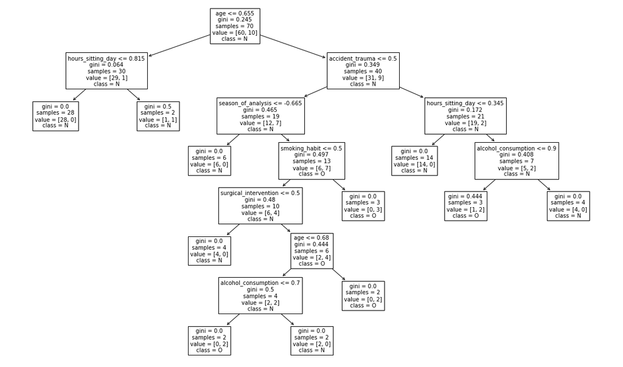

```python
feature_names = fertility_df.columns[:9]
class_names = ['N', 'O']
plt.figure(figsize=(20,12))
tree.plot_tree(clf, fontsize=10, feature_names=feature_names, class_names=class_names)
plt.show()
```

Now that we have made a decision tree on our training data, let's test it on our test data.

```python
y_pred = clf.predict(test.drop(['diagnosis'],axis=1))
y_test = test['diagnosis']
```

```python
print(confusion_matrix(y_test, y_pred))
print(classification_report(y_test, y_pred))
```

```
[[23  5]
 [ 1  1]]
              precision    recall  f1-score   support

           N       0.96      0.82      0.88        28
           O       0.17      0.50      0.25         2

    accuracy                           0.80        30
   macro avg       0.56      0.66      0.57        30
weighted avg       0.91      0.80      0.84        30
```

How to interpret the classification report:  
For more mathematical definitions with the report, please refer to an artcile like [Understanding the Classification Report in SKLearn](https://muthu.co/understanding-the-classification-report-in-sklearn/)  
Precision, what percentage of *our* classifications were correct?

- In terms of N / normal sperm, we were about 96% correct.
- In term of O / abnormal sperm, we were 17% correct.

Recall, what percentage of positives did you catch from the test data?

- In terms of N / normal sperm, we caught about 82%.
- In terms of O / abnormal sperm, we caught 50%.

> As a rule of thumb, the weighted average of F1 should be used to compare classifier models, not global accuracy.

Our f1 weighted average is about 84% which is nice! This may be good for trying things out, but if you want better accuracy in the real world you may have to play around with parameters.

Note: The f1-score is a combination of precision and recall.

## Insight and Policy Decision

We won't be making any policy decisions here, but we will be making some insights about the data we have encountered in this data science pipeline tutorial.

Regarding a connection between our numerical variables: age and hours sitting in a day, we found that there was a significant negative linear relationship between the two at least with the ages covered in this survey of 18-36 year old people.

**Fertility insights**  
It is quite surprising that we found the only significant variable to be accident or serious trauma, with more abnormal sperm found in the group with *no* accidents or serious trauma. Perhaps this data is skewed, especially with so few participants, or it could be that something about having a serious accident or trauma really has something to do with sperm. There is one, thing, it does warrant more investigation. In data science, you can do research and analyze data and also *go back* in the pipeline. This is an instance where possibly going back would be helpful, was it something with the participants themselves, or could we have done different analysis? Could we have asked this question better to see what could have happened? There are endless questions, and sometimes we have to keep on repeating different parts of the pipeline to get our answers.

As for our model, we were able to predict with about ~80% accuracy of a normal or abnormal sperm diagnosis. We tried to avoid overfitting our data by setting our minimum leaves to 2. However, that doesn't mean we were that successful. Plus, it doesn't help that our test data was imbalanced, partially because so many of the patients had normal sperm out of the 100. Perhaps more data collection can be done here.

Were we able to get great insights? Maybe, but there are more tests to be done!

**Here are some helpful links to consider:**

If you are interested in a professional analysis of this dataset, please refer to the actual paper in *Oxford Academics*:  
[Semen Parameters Can Be Predicted from Environmental Factors and Lifestyle Using Artificial Intelligence Methods](https://academic.oup.com/biolreprod/article/88/4/99,%201-8/2514098)

If you are interested in learning more about data science, please refer to an academic course like CMSC320 at the University of Maryland, College Park: [CMSC 320 Spring 2021](https://cmsc320.github.io/)